# Project 2: Data Mining, Classification, Prediction

SDS322E

# Mining, Classification, Prediction

## Xiaoyu Zhou, xz7363

### Introduction

This dataset contains 12 features that can be used to predict mortality by heart failure, such as age, gender, creatinine phosphokinase level, platelets level, etc. All the numerical variables are measuring the levels of each features, such as serum sodium measures serum sodium levels, etc. For all the binary variables, “1” means positive and “0” means negative, while for sex, “1” means male, “0” means female. They are interesting to me because heart failure has been taking millions of lives each year and this data may help us understand the reasons behind it or even prevent it. This dataset is from website: https://www.kaggle.com/, and it contains 299 observations. In the dataset, 129 observations have anaemia and 170 observations do not; 125 observations have diabetes and 174 observations do not; 105 observations have high blood pressure and 194 observations do not; 95 observations smoke and 204 observations do not; 96 observations have death event and 203 observations do not; and lastly, 196 observations are male and 103 observations are female.

```r
library(tidyverse)
data <- read_csv("heart_failure_clinical_records_dataset.csv")
data
```

```
## # A tibble: 299 x 13
##      age anaemia creatinine_phos… diabetes ejection_fracti… high_blood_pres…
##    <dbl>   <dbl>            <dbl>    <dbl>            <dbl>            <dbl>
##  1    75       0              582        0               20                1
##  2    55       0             7861        0               38                0
##  3    65       0              146        0               20                0
##  4    50       1              111        0               20                0
##  5    65       1              160        1               20                0
##  6    90       1               47        0               40                1
##  7    75       1              246        0               15                0
##  8    60       1              315        1               60                0
##  9    65       0              157        0               65                0
## 10    80       1              123        0               35                1
## # … with 289 more rows, and 7 more variables: platelets <dbl>,
## #   serum_creatinine <dbl>, serum_sodium <dbl>, sex <dbl>, smoking <dbl>,
## #   time <dbl>, DEATH_EVENT <dbl>
```

```r
heart <- data %>% mutate(anaemia1 = ifelse(anaemia == 1, "yes",
    "no"), diabetes1 = ifelse(diabetes == 1, "yes", "no"), high_blood_pressure1 = ifelse(high_blood_pressure ==
    1, "yes", "no"), smoking1 = ifelse(smoking == 1, "yes", "no"),
    death_event = ifelse(DEATH_EVENT == 1, "yes", "no"), gender = ifelse(sex ==
        1, "male", "female")) %>% select(-anaemia, -diabetes,
    -high_blood_pressure, -smoking, -DEATH_EVENT, -sex)
heart
```

```
## # A tibble: 299 x 13
##      age creatinine_phos… ejection_fracti… platelets serum_creatinine
##    <dbl>            <dbl>            <dbl>     <dbl>            <dbl>
##  1    75              582               20   265000               1.9
##  2    55             7861               38   263358.              1.1
##  3    65              146               20   162000               1.3
##  4    50              111               20   210000               1.9
##  5    65              160               20   327000               2.7
##  6    90               47               40   204000               2.1
##  7    75              246               15   127000               1.2
##  8    60              315               60   454000               1.1
##  9    65              157               65   263358.              1.5
## 10    80              123               35   388000               9.4
## # … with 289 more rows, and 8 more variables: serum_sodium <dbl>, time <dbl>,
## #   anaemia1 <chr>, diabetes1 <chr>, high_blood_pressure1 <chr>,
## #   smoking1 <chr>, death_event <chr>, gender <chr>
```

### Cluster Analysis

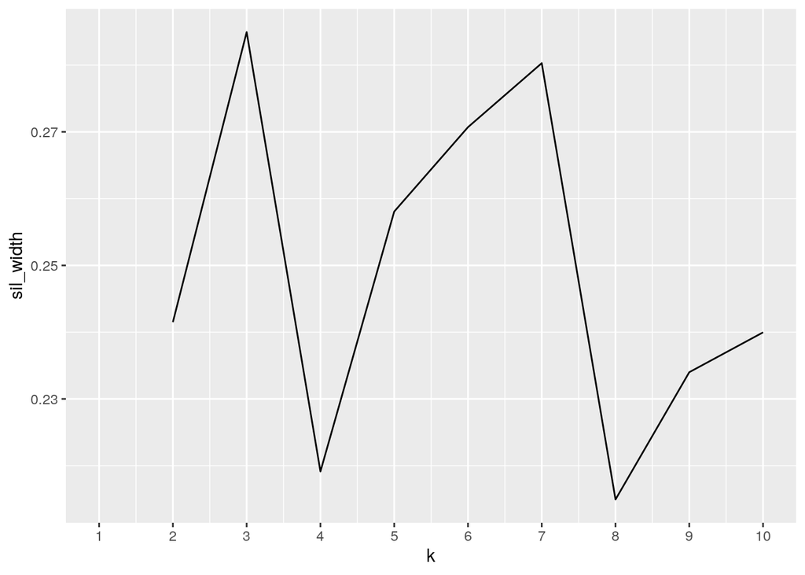

```r
library(cluster)
pam_dat <- data %>% select(creatinine_phosphokinase, platelets,
    serum_sodium) %>% scale
sil_width <- vector()
for (i in 2:10) {
    pam_fit <- pam(pam_dat, k = i)
    sil_width[i] <- pam_fit$silinfo$avg.width
}
ggplot() + geom_line(aes(x = 1:10, y = sil_width)) + scale_x_continuous(name = "k",
    breaks = 1:10)
```

```r
sil_width
```

```
##  [1]        NA 0.2415031 0.2849417 0.2191295 0.2580618 0.2707036 0.2802912
##  [8] 0.2149345 0.2340017 0.2399675
```

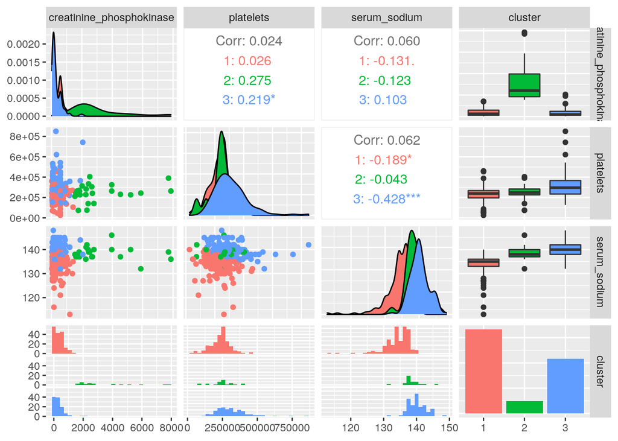

```r
pam2 <- data %>% select(creatinine_phosphokinase, platelets,
    serum_sodium) %>% scale %>% pam(3)
library(GGally)
data %>% select(creatinine_phosphokinase, platelets, serum_sodium) %>%
    mutate(cluster = as.factor(pam2$clustering)) %>% ggpairs(cols = 1:3,
    aes(color = cluster))
```

The average Silhouette Width is 0.28 when k=3, which means that the structure is weak and could be artificial. The clusters have the most difference on creatinine phosphokinase and the least difference on platelets.

### Dimensionality Reduction with PCA

```r
heart1 <- heart %>% select_if(is.numeric) %>% scale
pca1 <- princomp(heart1, cor = T)
summary(pca1, loadings = T)
```

```
## Importance of components:
##                           Comp.1    Comp.2    Comp.3    Comp.4    Comp.5
## Standard deviation     1.2143198 1.0842469 1.0146325 0.9829678 0.9421964
## Proportion of Variance 0.2106532 0.1679416 0.1470685 0.1380322 0.1268192
## Cumulative Proportion  0.2106532 0.3785949 0.5256633 0.6636956 0.7905147
##                           Comp.6    Comp.7
## Standard deviation     0.8587448 0.8537882
## Proportion of Variance 0.1053490 0.1041363
## Cumulative Proportion  0.8958637 1.0000000
##
## Loadings:
##                          Comp.1 Comp.2 Comp.3 Comp.4 Comp.5 Comp.6 Comp.7
## age                       0.465  0.452         0.198  0.191  0.634  0.318
## creatinine_phosphokinase -0.138 -0.194 -0.815  0.334 -0.295  0.101  0.265
## ejection_fraction        -0.179  0.681  0.107        -0.469 -0.391  0.344
## platelets                -0.199  0.247 -0.403 -0.821  0.181  0.173
## serum_creatinine          0.512        -0.102 -0.182 -0.634  0.107 -0.529
## serum_sodium             -0.447  0.430 -0.118  0.363  0.151  0.187 -0.642
## time                     -0.481 -0.214  0.371 -0.100 -0.446  0.599  0.135
```

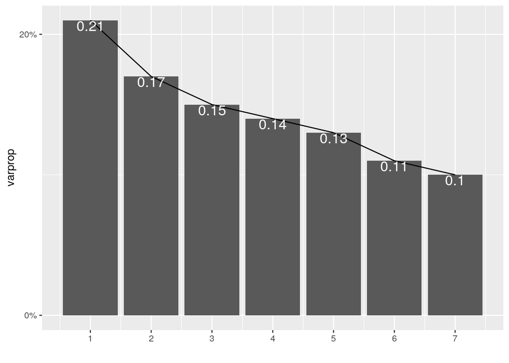

```r
eigval <- pca1$sdev^2
varprop = round(eigval/sum(eigval), 2)
ggplot() + geom_bar(aes(y = varprop, x = 1:7), stat = "identity") +
    xlab("") + geom_path(aes(y = varprop, x = 1:7)) + geom_text(aes(x = 1:7,
    y = varprop, label = round(varprop, 2)), vjust = 1, col = "white",
    size = 5) + scale_y_continuous(breaks = seq(0, 0.6, 0.2),
    labels = scales::percent) + scale_x_continuous(breaks = 1:10)
```

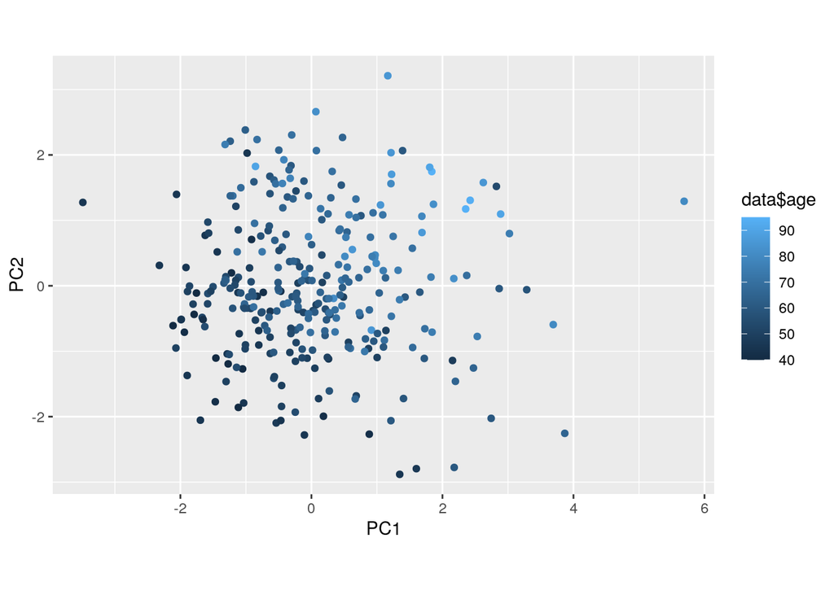

```r
scores <- pca1$scores
scores %>% as.data.frame %>% mutate(PC1 = pca1$scores[, 1], PC2 = pca1$scores[,
    2]) %>% ggplot(aes(PC1, PC2)) + geom_point(aes(color = data$age)) +
    coord_fixed()
```

PC1 is age/serum creatinine vs. other numerical variables, higher PC1 score means higher age/creatinine and lower other numerical variables; PC2 is CP/time vs. age/ejection fraction/platelets/serum sodium, lower PC2 score means higher CP/time and lower age/ejection fraction/platelets/serum sodium; PC3 is ejection fraction/time vs. CP/platelets/serum creatinine/serum sodium, higher PC3 score means higher ejection fraction/time and lower CP/platelets/serum creatinine/serum sodium. PC4 is age/CP/serum sodium vs. platelets/serum creatinine/time, higher PC4 score means higher age/CP/serum sodium and lower platelets/serum creatinine/time. PC5 is age/platelets/serum sodium vs. CP/ejection fraction/serum creatinine/time, higher PC5 score means higher age/platelets/serum sodium and lower CP/ejection fraction/serum creatinine/time. At the end, 79% of total variance in the dataset is explained by these PCs.

### Linear Classifier

```r
heart
```

```
## # A tibble: 299 x 13
##      age creatinine_phos… ejection_fracti… platelets serum_creatinine
##    <dbl>            <dbl>            <dbl>     <dbl>            <dbl>
##  1    75              582               20   265000               1.9
##  2    55             7861               38   263358.              1.1
##  3    65              146               20   162000               1.3
##  4    50              111               20   210000               1.9
##  5    65              160               20   327000               2.7
##  6    90               47               40   204000               2.1
##  7    75              246               15   127000               1.2
##  8    60              315               60   454000               1.1
##  9    65              157               65   263358.              1.5
## 10    80              123               35   388000               9.4
## # … with 289 more rows, and 8 more variables: serum_sodium <dbl>, time <dbl>,
## #   anaemia1 <chr>, diabetes1 <chr>, high_blood_pressure1 <chr>,
## #   smoking1 <chr>, death_event <chr>, gender <chr>
```

```r
logistic_fit <- glm(death_event == "yes" ~ age + creatinine_phosphokinase +
    ejection_fraction + platelets + serum_creatinine + serum_sodium +
    time, data = heart, family = "binomial")
prob_reg <- predict(logistic_fit, type = "response")
table(truth = factor(heart$death_event == "yes", levels = c("TRUE",
    "FALSE")), prediction = factor(prob_reg > 0.5, levels = c("TRUE",
    "FALSE")))
```

```
##        prediction
## truth   TRUE FALSE
##   TRUE    66    30
##   FALSE   18   185
```

```r
class_diag(prob_reg, truth = heart$death_event, positive = "yes")
```

```
##            acc   sens   spec    ppv     f1     ba    auc
## Metrics 0.8395 0.6875 0.9113 0.7857 0.7333 0.7994 0.8959
```

```r
set.seed(322)
k = 10
sample <- sample_frac(heart)
folds <- rep(1:k, length.out = nrow(sample))
diags <- NULL
i = 1
for (i in 1:k) {
    train <- sample[folds != i, ]
    test <- sample[folds == i, ]
    truth <- test$death_event
    fit <- glm(death_event == "yes" ~ age + creatinine_phosphokinase +
        ejection_fraction + platelets + serum_creatinine + serum_sodium +
        time, data = train, family = "binomial")
    probs <- predict(fit, newdata = test, type = "response")
    diags <- rbind(diags, class_diag(probs, truth, positive = "yes"))
}
summarize_all(diags, mean)
```

```
##       acc    sens    spec    ppv      f1      ba     auc
## 1 0.81919 0.69288 0.88694 0.7563 0.70567 0.78992 0.88222
```

The logistic regression model is performing good with an AUC of 0.8959. When predicting new observations in cross-validation, this model is also performing good with an AUC of 0.8822. Therefore, there is no sign of decrease in AUC which means no sign of overfitting.

### Non-Parametric Classifier

```r
library(caret)
knn_fit <- knn3(death_event == "yes" ~ age + creatinine_phosphokinase +
    ejection_fraction + platelets + serum_creatinine + serum_sodium +
    time, data = heart)
prob_knn <- predict(knn_fit, heart)
prob_knn
```

[output not shown]

[output cut: 37 more lines]

```r
table(truth = factor(heart$death_event == "yes", levels = c("TRUE",
    "FALSE")), prediction = factor(prob_knn[, 1] > 0.5, levels = c("TRUE",
    "FALSE")))
```

```
##        prediction
## truth   TRUE FALSE
##   TRUE    57    39
##   FALSE  185    18
```

```r
class_diag(prob_knn[, 2], truth = heart$death_event, positive = "yes")
```

```
##            acc   sens   spec    ppv     f1     ba    auc
## Metrics 0.7492 0.4062 0.9113 0.6842 0.5098 0.6588 0.7612
```

```r
set.seed(322)
k = 10
sample <- sample_frac(heart)
folds <- rep(1:k, length.out = nrow(sample))
diags <- NULL
i = 1
for (i in 1:k) {
    train <- sample[folds != i, ]
    test <- sample[folds == i, ]
    truth <- test$death_event
    fit <- knn3(death_event == "yes" ~ age + creatinine_phosphokinase +
        ejection_fraction + platelets + serum_creatinine + serum_sodium +
        time, data = heart)
    probs <- predict(fit, newdata = test)[, 2]
    diags <- rbind(diags, class_diag(probs, truth, positive = "yes"))
}
summarize_all(diags, mean)
```

```
##       acc    sens  spec     ppv  f1      ba     auc
## 1 0.74942 0.40241 0.911 0.64547 NaN 0.65671 0.76276
```

### Regression/Numeric Prediction

```r
heart
```

```
## # A tibble: 299 x 13
##      age creatinine_phos… ejection_fracti… platelets serum_creatinine
##    <dbl>            <dbl>            <dbl>     <dbl>            <dbl>
##  1    75              582               20   265000               1.9
##  2    55             7861               38   263358.              1.1
##  3    65              146               20   162000               1.3
##  4    50              111               20   210000               1.9
##  5    65              160               20   327000               2.7
##  6    90               47               40   204000               2.1
##  7    75              246               15   127000               1.2
##  8    60              315               60   454000               1.1
##  9    65              157               65   263358.              1.5
## 10    80              123               35   388000               9.4
## # … with 289 more rows, and 8 more variables: serum_sodium <dbl>, time <dbl>,
## #   anaemia1 <chr>, diabetes1 <chr>, high_blood_pressure1 <chr>,
## #   smoking1 <chr>, death_event <chr>, gender <chr>
```

```r
fit <- lm(age ~ ., data = heart)  #predict mpg from all other variables
yhat <- predict(fit)  #predicted mpg
mean((heart$age - yhat)^2)
```

```
## [1] 123.3761
```

```r
set.seed(1234)
k = 5
samp <- heart[sample(nrow(heart)), ]  #randomly order rows
folds <- cut(seq(1:nrow(heart)), breaks = k, labels = F)  #create folds
diags <- NULL
for (i in 1:k) {
    train <- heart[folds != i, ]
    test <- heart[folds == i, ]
    ## Fit linear regression model to training set
    fit <- lm(age ~ ., data = train)
    ## Get predictions/y-hats on test set (fold i)
    yhat <- predict(fit, newdata = test)
    ## Compute prediction error (MSE) for fold i
    diags <- mean((test$age - yhat)^2)
}
mean(diags)
```

```
## [1] 122.6224
```

### Python

```r
library(reticulate)
use_python("/usr/bin/python3", required = F)
age <- heart$age
```

```python
x = max(r.age)
y = min(r.age)
print(x)
```

```
## 95.0
```

```python
print(y)
```

```
## 40.0
```

```r
range <- py$x - py$y
range
```

```
## [1] 55
```

Maximum and minimum of age are calculated in Python chunk and range is calculated in the following R chunk.